# Projekt_faza_3

Gabriela Jaworska: mapy (dla sekwencji), klastry +20, korekta skryptu, Michał Jaworski: analiza przejść bezpośrednich, Jan Rosa: pomysł badania, analiza klastrów (poza +20), analiza reguł asocjacyjnych oraz sekwencji, regresja

# Wstęp

Stacje cnk19, cnk02, cnk18, cnk12 i cnk16 są odwiedzane przez znaczną część gości Centrum Nauki Kopernik. Ze względu na ich popularność, to co prezentują może, w znacznym stopniu, rzutować na recepcję całej wystawy. W naszej pracy postaramy się przeanalizować jak wymienione wyżej stacje wpływają na decyzje gości: czy zachęcają do obejrzenia mniej popularnych eksponatów, czy tylko tych najpopularniejszych? Zbadamy bezpośredni jak i pośredni ich wpływ, zarówno dla wszystkich odwiedzających jak i dla szczególnych grup gości.

W analizie wyróżniliśmy dwa typy popularnych stacji, do których będziemy starali się dopasować analizowane eksponaty:

1. stacje “tranzytowe” - stacje popularne nie zachęcające jednak gości do zobaczenia innych, mniej popularnych stacji, kierujące odwiedzających do innych najbardziej popularnych stacji,
2. stacje “inspirujące” - stacje popularne jednocześnie zachęcające do zobaczenia mniej popularnych, być może podobnych tematycznie, stacji.

Jednocześnie należy zdawać sobie sprawę, że ustawienie eksponatów może mieć duży wpływ na typ stacji.

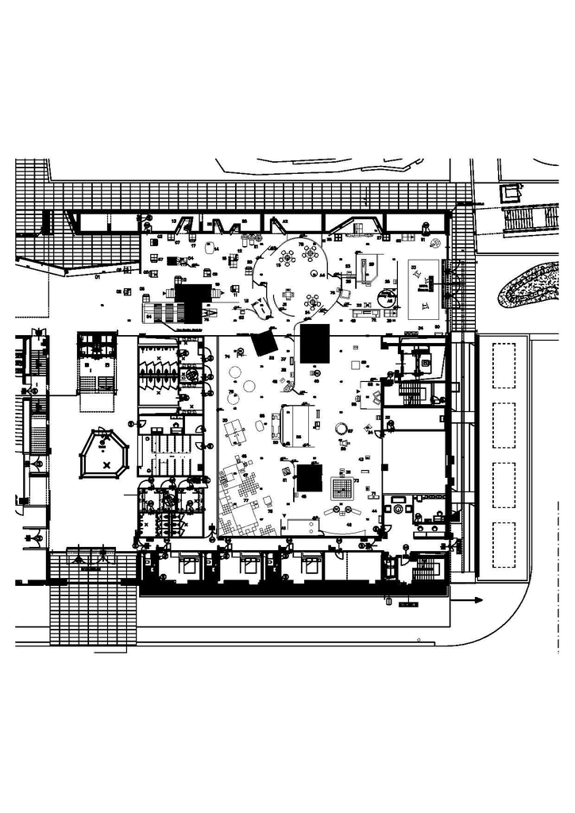

Na mapce widać, że stacji cnk02 najtrudniej być “inspirującą”, gdyż jest ona zwykle odwiedzana w pierwszej kolejności i najbliżej z niej do pozostałych popularnych stacji.

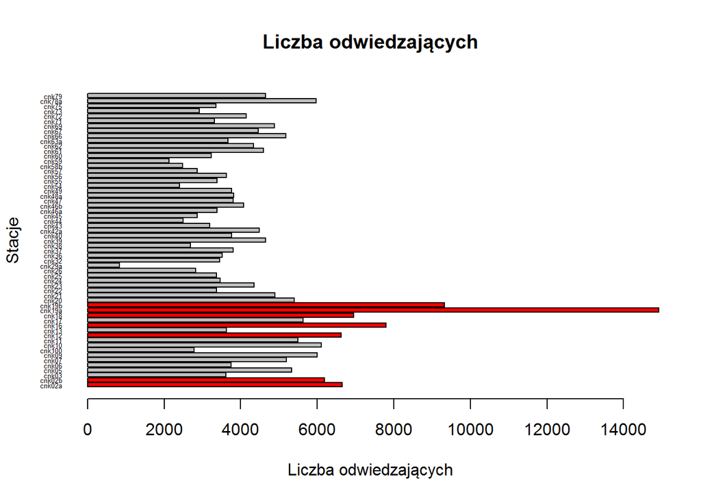

# Macierze przejścia pomiędzy wybranymi stacjami

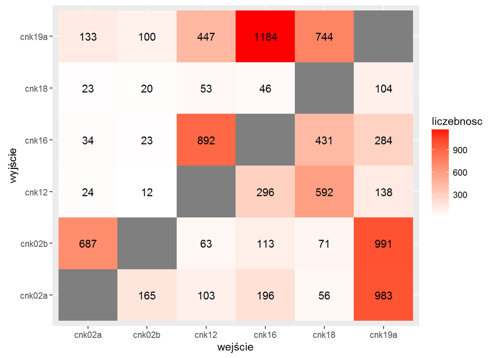

Powyższa macierz składa się z liczby bezpośrednich przejść pomiędzy najbardziej popularnymi stacjami (cnk02, cnk12, cnk16, cnk18, cnk19). Na podstawie tej macierzy ciepła zauważamy, że najczęstsze bezpośrednie przejścia to:

1. z cnk02a, cnk02b do cnk19 - jest to najprawdopodobniej spowodowane tym, że cnk02a, cnk02b są bardzo często stacjami “startowymi” natomiast stacja cnk19a jest jedną z najbliższych popularnych stacji.
2. z cnk19 do cnk16 - stacje te leżą najbliżej siebie spośród pozostałych popularnych.
3. z cnk16 do cnk12 - ponownie są to dwa popularne eksponaty znajdujące się obok siebie. Zauważamy jednak, że znacznie częściej występuje przejście z cnk16 do cnk12 niż odwrotne. Powodem tego jest to, że większość zwiedzających przechodzi z najpopularniejszej stacji (cnk19) własnie do cnk16 i dopiero później decyduje się odwiedzić cnk12 (wynika to z lokalizacji każdej ze stacji).
4. z cnk12 do cnk18.

Podsumowując, na podstawie macierzy możemy stwierdzić, że stosunkowo duża część odwiedzających zaczyna od stacji cnk02 następnie odwiedza kolejno: cnk19, cnk16, cnk12, cnk18. Eksponat cnk18 jest najczęściej ostatnim odwiedzanym popularnym eksponatem. Wynika to z tego, że jest on położony najdalej od wejścia spośród innych popularnych stacji.

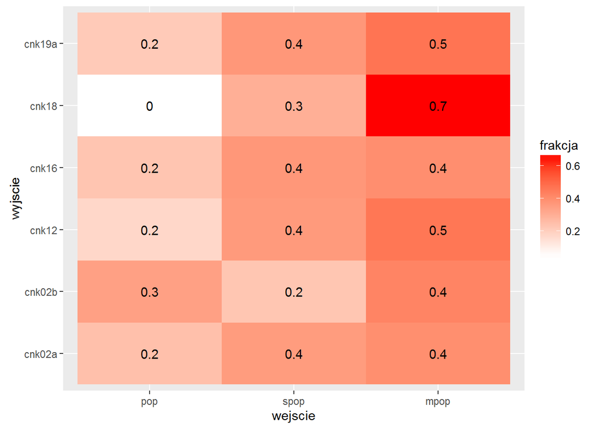

Powyższa macierz przedstawia stosunek przejść z wyszczególnionych stacji popularnych do stacji popularnych (cnk02, cnk12, cnk16, cnk18, cnk19), średnio-popularnych (cnk10, cnk09, cnk78a, cnk17, cnk11, cnk20, cnk05, cnk07), mało-popularnych (pozostałe, 43 stacje). Na podstawie macierzy można zauważyć, że dwie stacje odstają od pewnej prawidłowości. Mianowicie, ze stacji cnk02b wychodzi stosunkowo więcej osób do zbioru stacji popularnych niż do średnio-popularnych (mimo, iż liczba eksponatów w zbiorze stacji popularnych jest o dwa mniejsza). Jest to spowodowane tym, że bardzo duża część zwiedzających przechodzi z tej stacji bezpośrednio do najpopularniejszego eksponatu cnk19a. Kolejną, wyróżniającą się stacją jest cnk18. Zauważamy, że stosunkowo bardzo mało osób (tylko ok. 5%) wychodząc z tej stacji odwiedza stacje popularne. Oczywiście, tak jak zostało to już opisane przy okazji analizy poprzedniej macierzy, jest to spowodowane tym, że stacja cnk18 jest najczęściej odwiedzanym ostatnim eksponatem spośród tych najpopularniejszych.

# Analiza typów zwiedzających

Nim przystąpimy do analizy wpływu najczęściej odwiedzanych stacji na decyzje odwiedzających warto się im bliżej przyjrzeć - sprawdzić, czy można ich podzielić na grupy o bardziej jednolitych charakterystykach, by później móc przeprowadzić analizę wpływu wybranych przez nas stacji na członków tych grup. Jest to rozwinięcie naszych analiz z fazy drugiej.

Analizę ograniczymy tylko do osób odwiedzających co najmniej 10 stacji, przy czym badać będziemy osobno gości, którzy odwiedzili [10,14] stacji, [15,19] oraz powyżej 20 stacji. Wybór takiego podziału jest dość arbitralny, jednak kierowaliśmy się podziałem na gości, którzy odwiedzili co najmniej 1/6 stacji, co najmniej 1/4, bądź też powyżej 1/3 stacji.

Gości zróżnicowaliśmy względem odwiedzonych stacji. Ponieważ przeprowadzenie analiz na pełnym miesiącu jest zbyt złożone obliczeniowo, analizy, za pomocą których wybraliśmy metodę skalowania, oraz sposób klastrowania przeprowadzono na jednym pełnym tygodniu. Działanie takie jest uprawnione, ponieważ w każdym tygodniu Centrum odwiedzały podobne grupy zwiedzających (nie było świąt, niezwykłych imprez).

## Wybór metody skalowania i podział zwiedzających na klastry

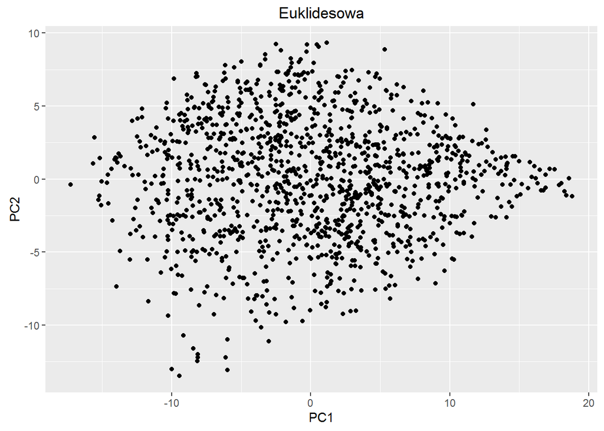

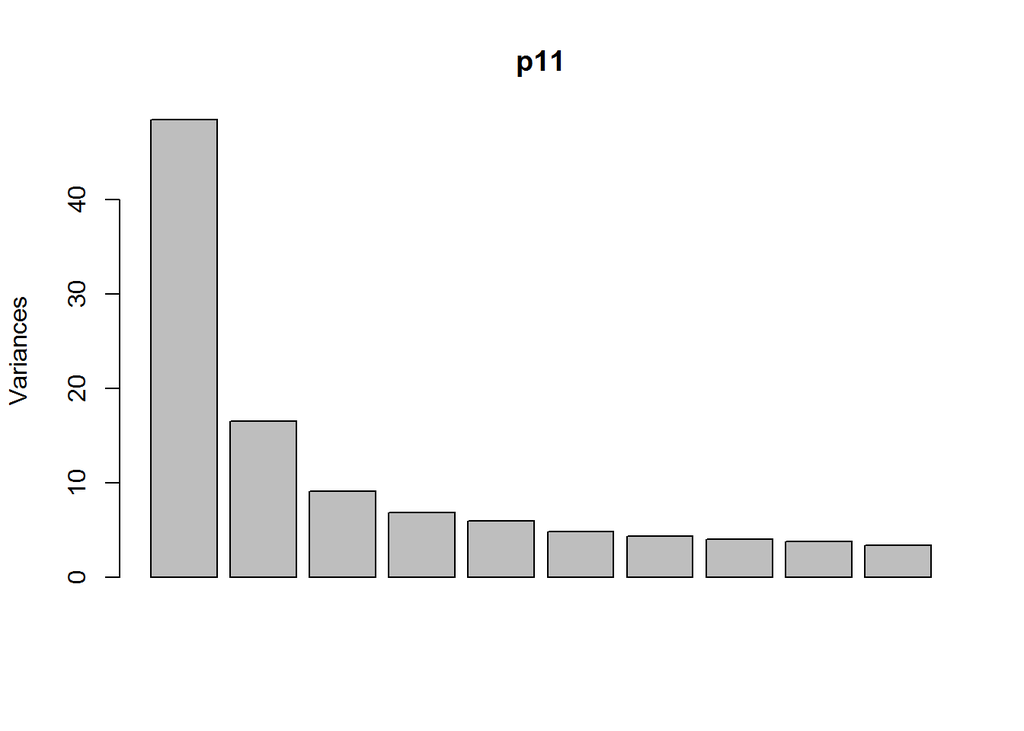

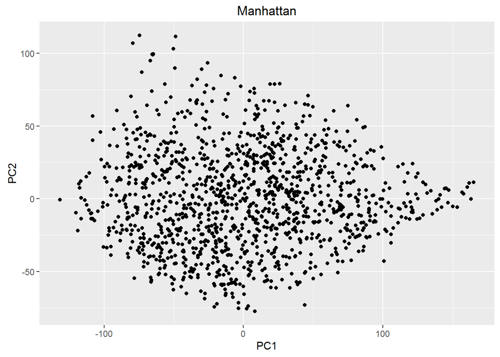

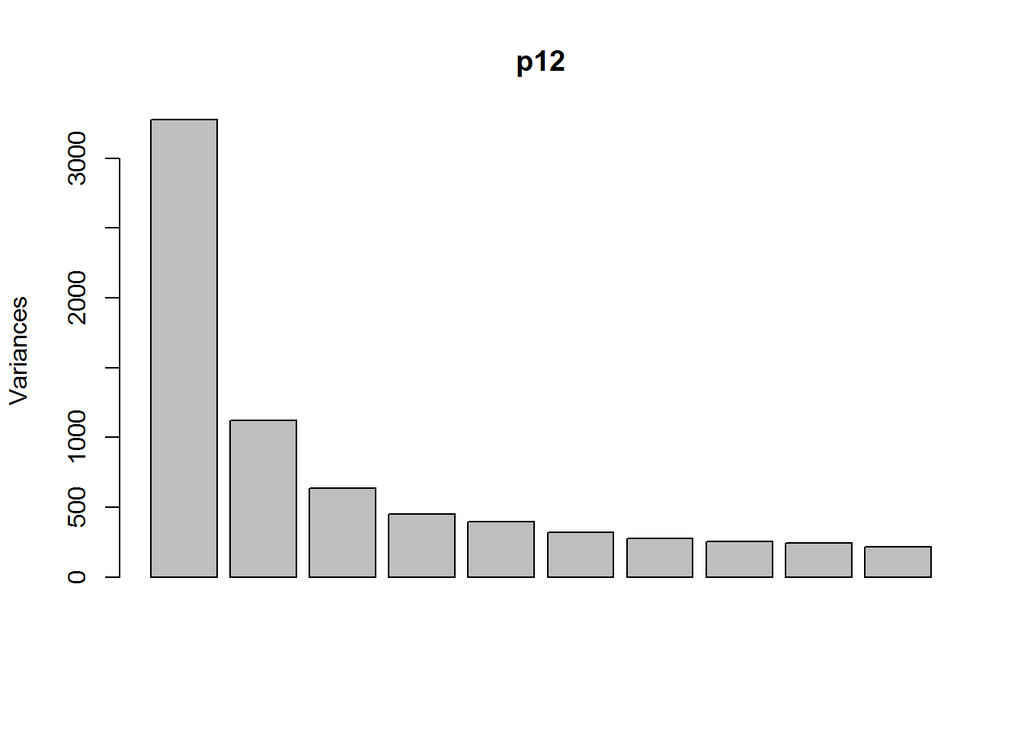

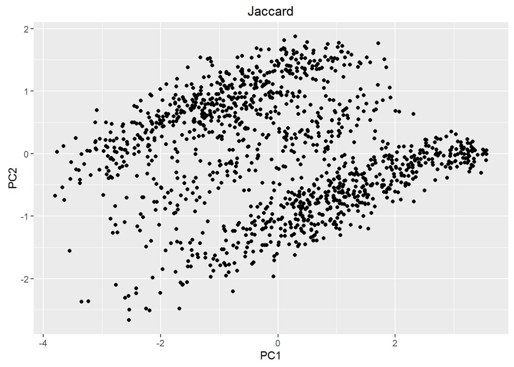

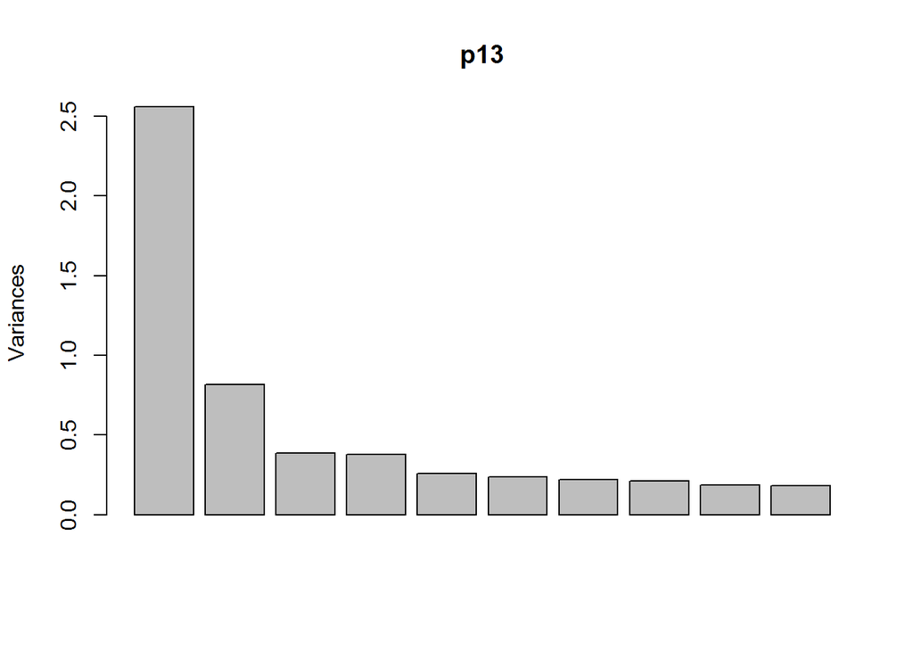

Ponieważ wygląd rzutowania punktów na dwa wymiary metodą PCA wskazało, iż skalowanie odległością euklidesową i metodą Manhattan dają podobne wyniki, porównamy jedynie skalowanie metodą Jaccarda i Manhattan.

Najpierw należy ustalić liczbę klastrów. Ponieważ w algorytmie eclust nie ma metryki Jaccarda, użyliśmy najbardziej zbliżonej metryki Canberra. Najpierw pokazano gap statistic dla metryki Manhattan, a następnie dla metryki Canberra.

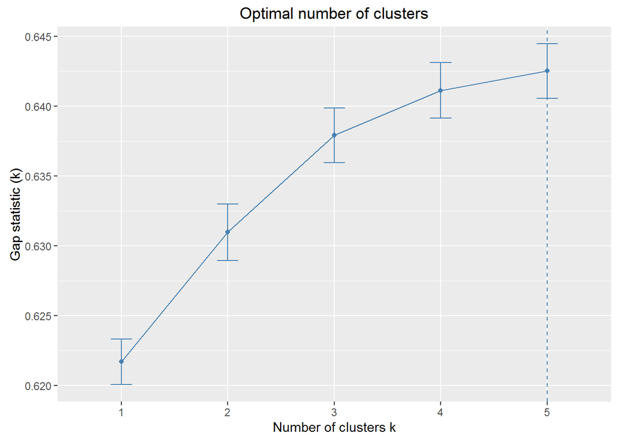

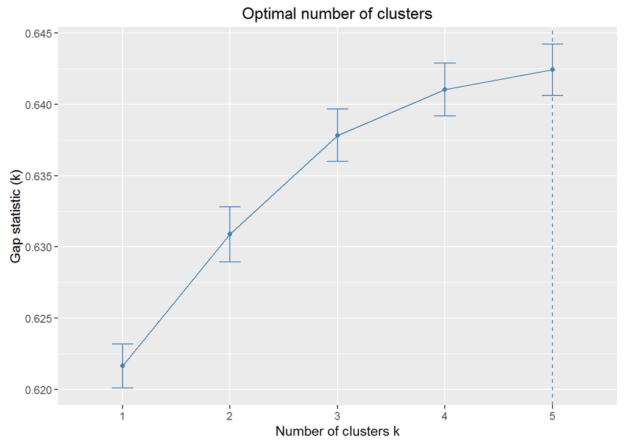

Klastrowano metodą Ward oraz metodą k-średnich, otrzymując następujące wyniki (rzut na dwa wymiary metodą PCA).

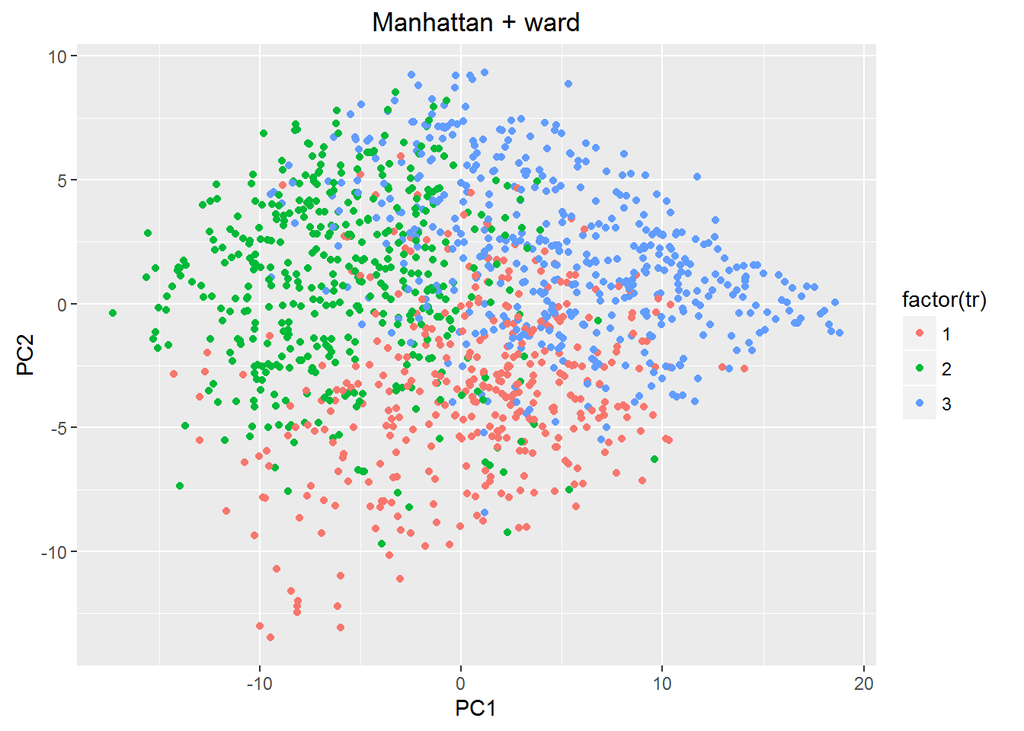

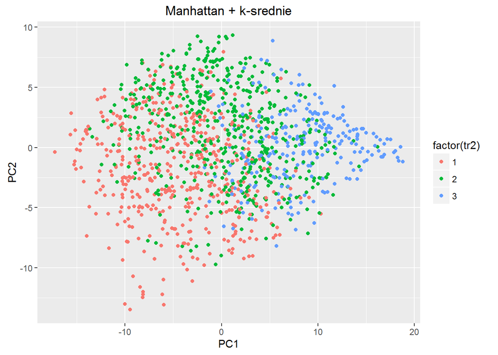

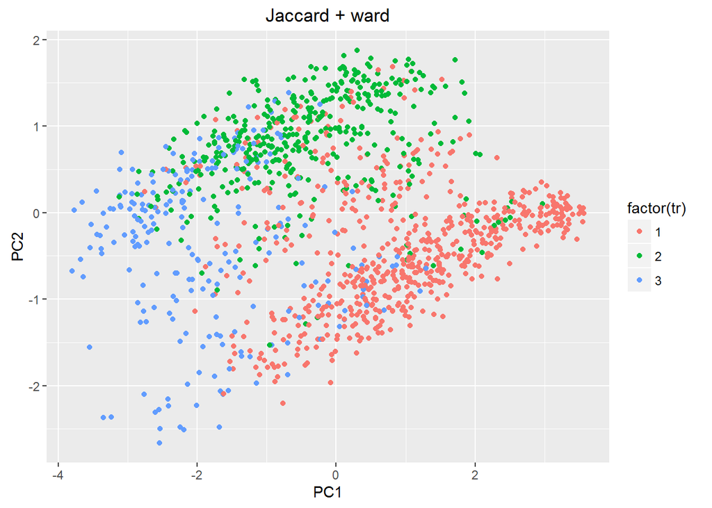

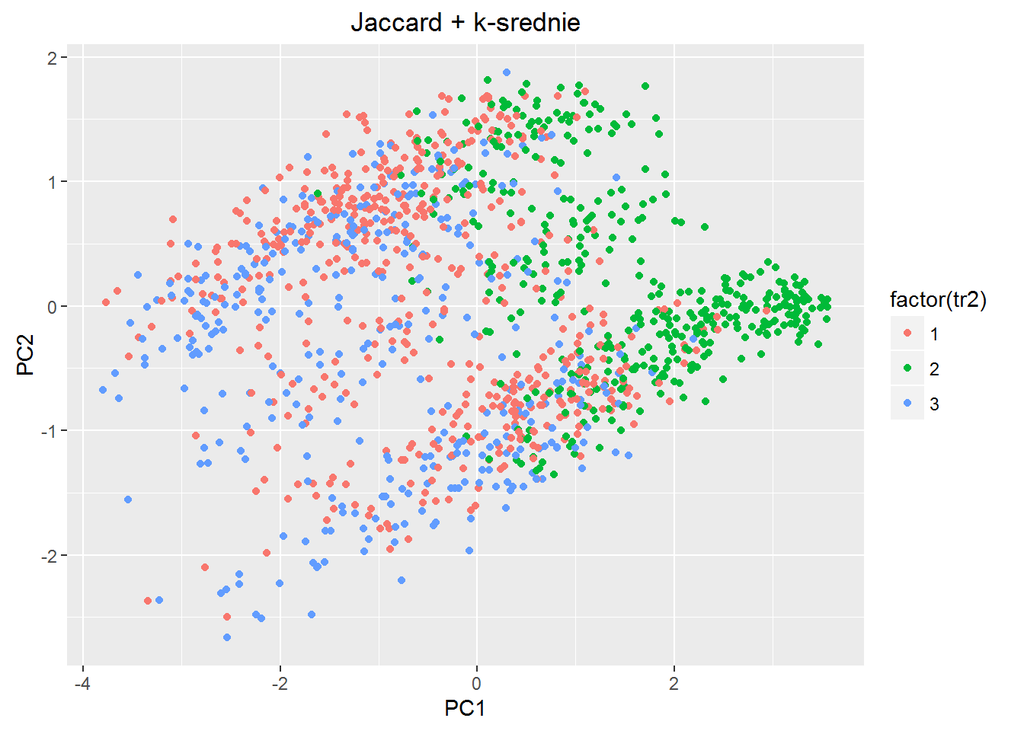

Wybrano metodę skalowania Manhattan oraz metodę klastrowania Ward, ponieważ podział na klastry wydawał się w tej parze najbardziej zgodny z rzutem.

Te same metody zastosowano przy klastrowaniu gości odwiedzających 15-19 stacji, aby zachować spójność analiz. W tym przypadku również wybrano podział na 3 klastry.

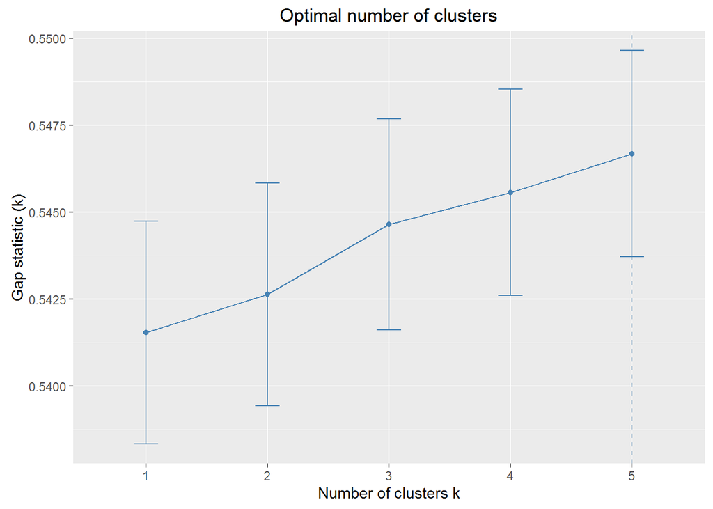

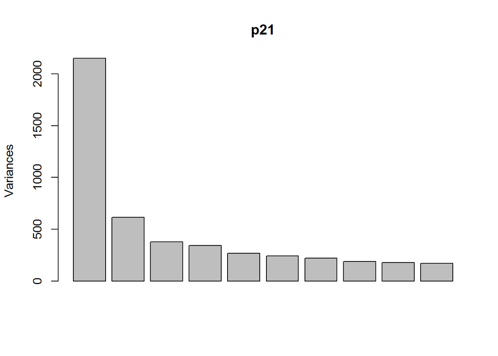

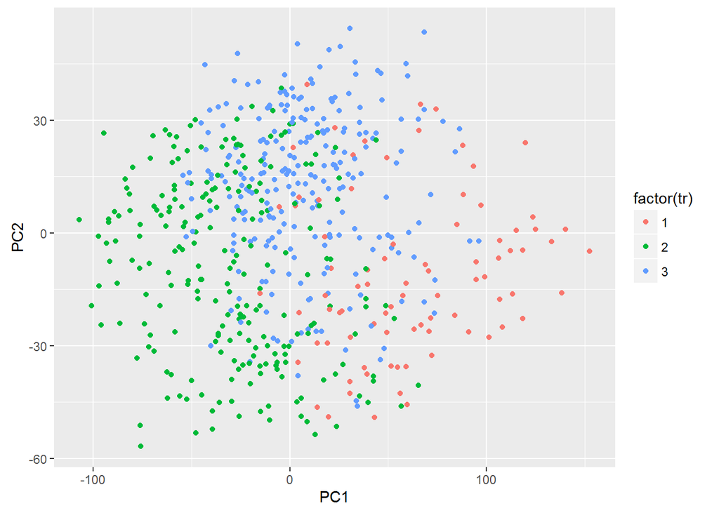

Dla osób zwiedzających powyżej 19 stacji użyto tych samych metod.

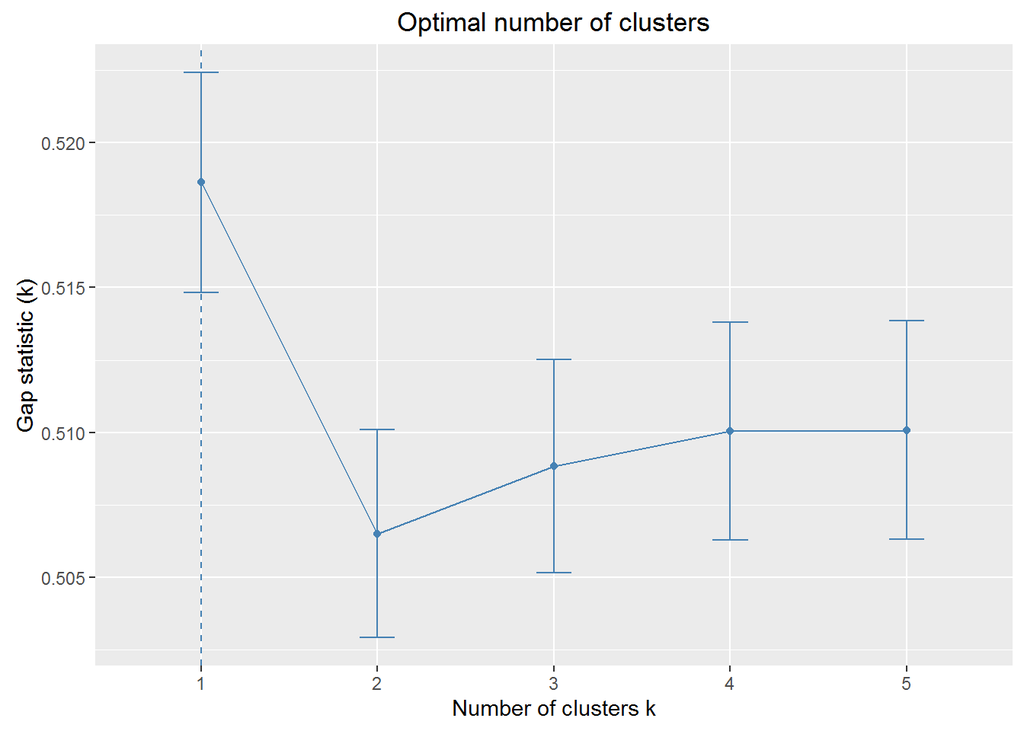

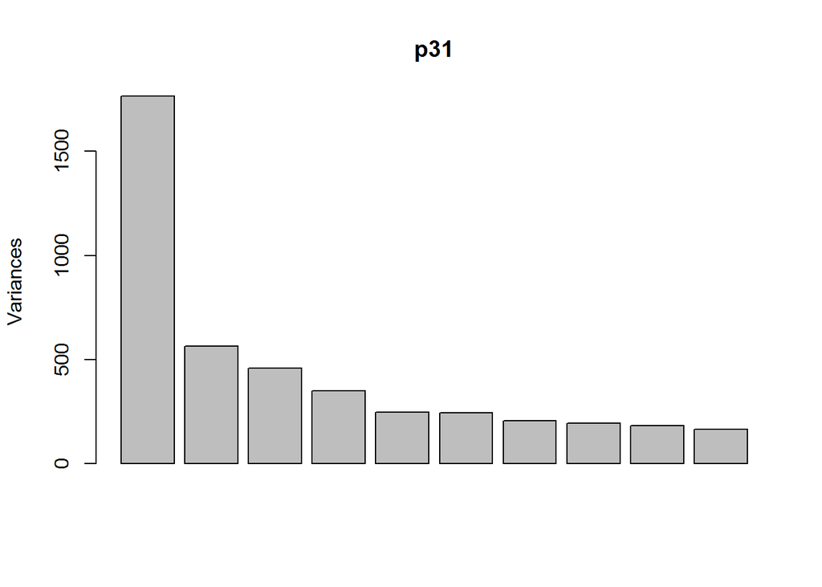

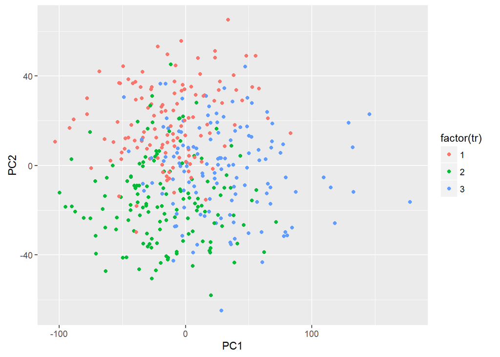

Nie zdecydowano się jednak na podział ze względu na małą zgodność rzutowania z podziałem oraz małą liczbę gości w tej grupie.

## Macierze ciepła ilustrujące przejścia między najbardziej popularnymi stacjami

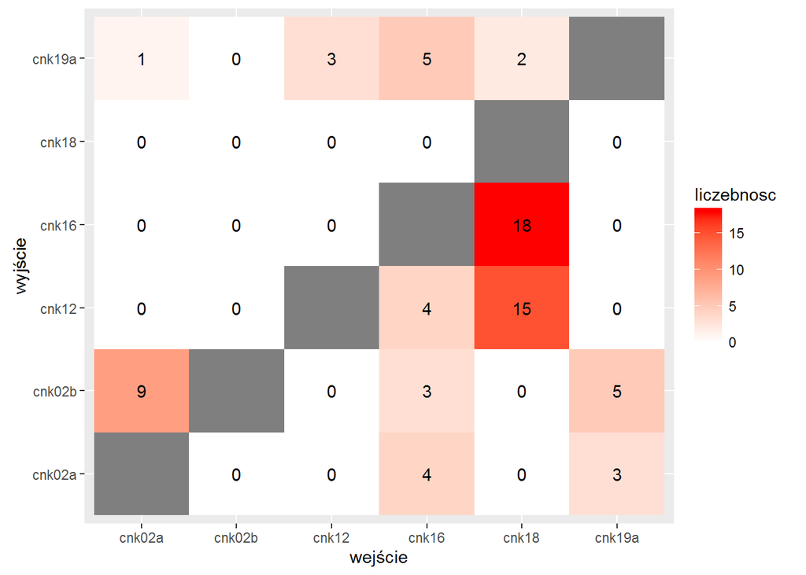

Powyższa macierz składająca się z liczby przejść pomiędzy najbardziej popularnymi stacjami (cnk02, cnk12, cnk16, cnk18, cnk19) dla I klastra wśród osób, które odwiedziły [10,14] eskponatów. Klaster ten charakteryzuje się tym, że stosunkowo wiele osób odwiedza stacje cnk12, cnk16 (przychodzi do nich ze stacji mniej popularnych), następnie przechodzą oni bezpośrednio do stacji cnk18.

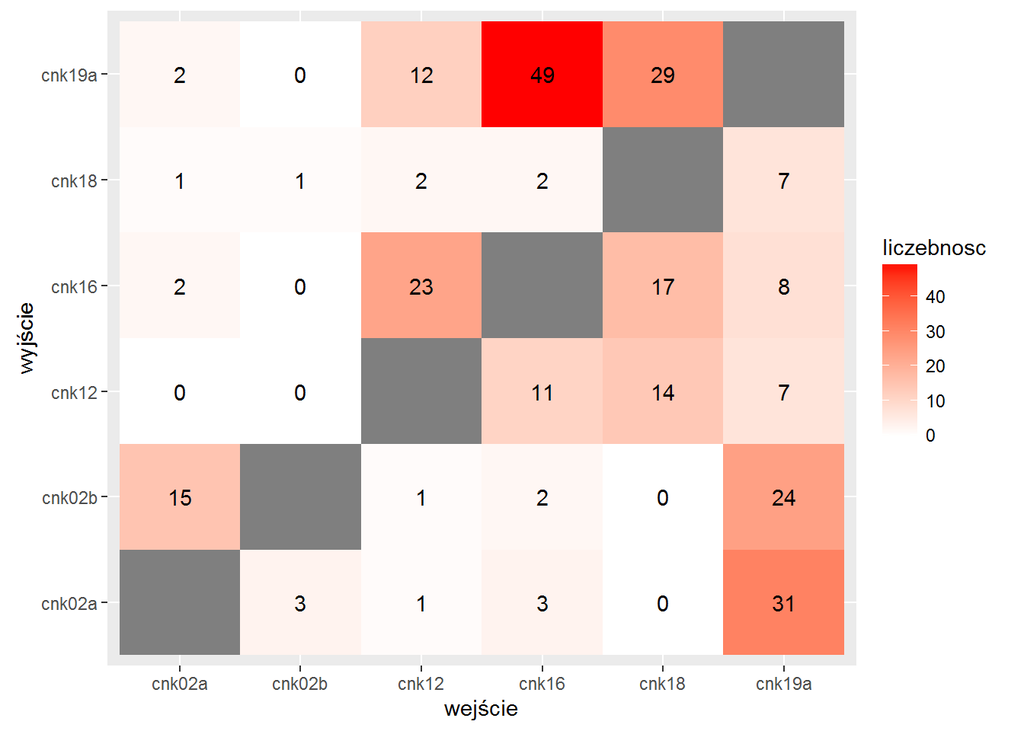

Powyższa macierz składająca się z liczby przejść pomiędzy najbardziej popularnymi stacjami (cnk02, cnk12, cnk16, cnk18, cnk19) dla II klastra wśród osób, które odwiedziły [10,14] eskponatów. Klaster II składa się z odwiedzających, którzy najczęściej przechodzą typową ścieżkę opisaną na samym początku raportu. Odwiedzają oni cnk02, następnie cnk19, później cnk16, cnk12, cnk18.

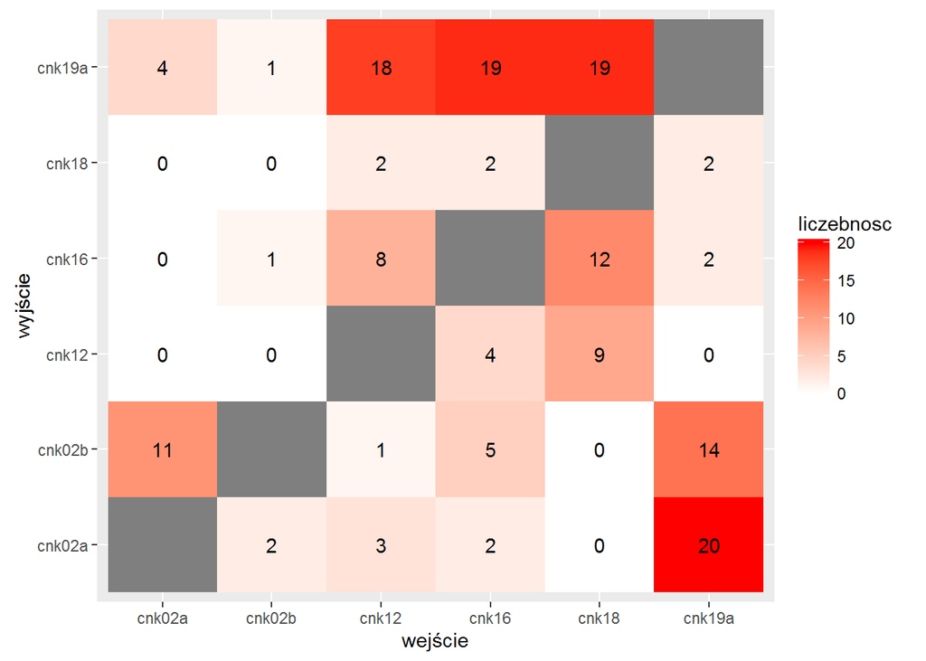

Powyższa macierz składająca się z liczby przejść pomiędzy najbardziej popularnymi stacjami (cnk02, cnk12, cnk16, cnk18, cnk19) dla III klastra wśród osób, które odwiedziły [10,14] eskponatów. Ten klaster, pod pewnymi względami, przypomina klaster II. Ponownie odwiedzający przechodzą kolejno przez cnk02, cnk19, jednak już z cnk19 równo rozchodzą się po stacjach cnk12, cnk16, cnk18. Niewielkie wartość w wierszach cnk12, cnk16, cnk18 mogą wskazywać, że nastepnie odwiedzający przechodzą do mniej popularnych eksponatów.

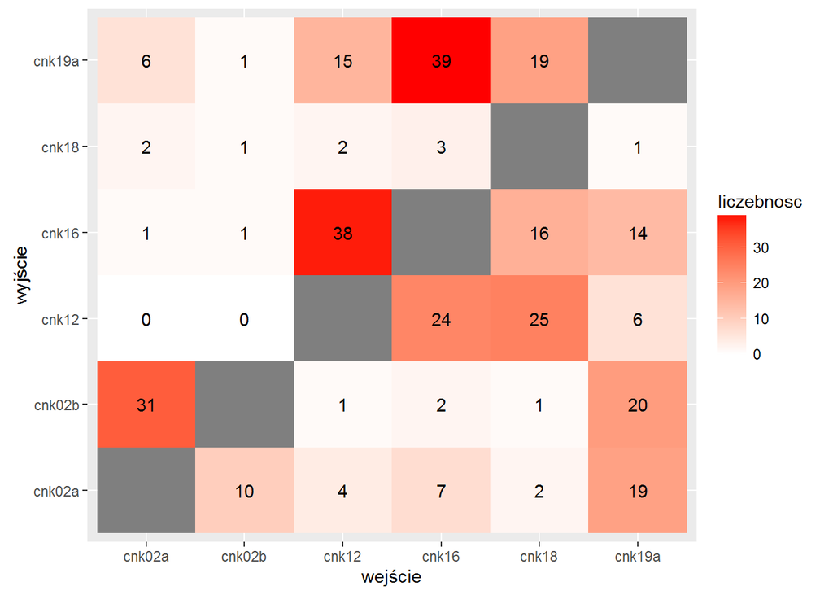

Powyższa macierz składająca się z liczby przejść pomiędzy najbardziej popularnymi stacjami (cnk02, cnk12, cnk16, cnk18, cnk19) wśród osób, które odwiedziły [15,19] eskponatów. W tym przypadku możemy po raz kolejny mówić o typowej kolejności zwiedzania najbardziej popularnych stacji. Podobnie sytuacja wygląda w przypadku osób, które odwiedziły ponad 20 eksponatów.

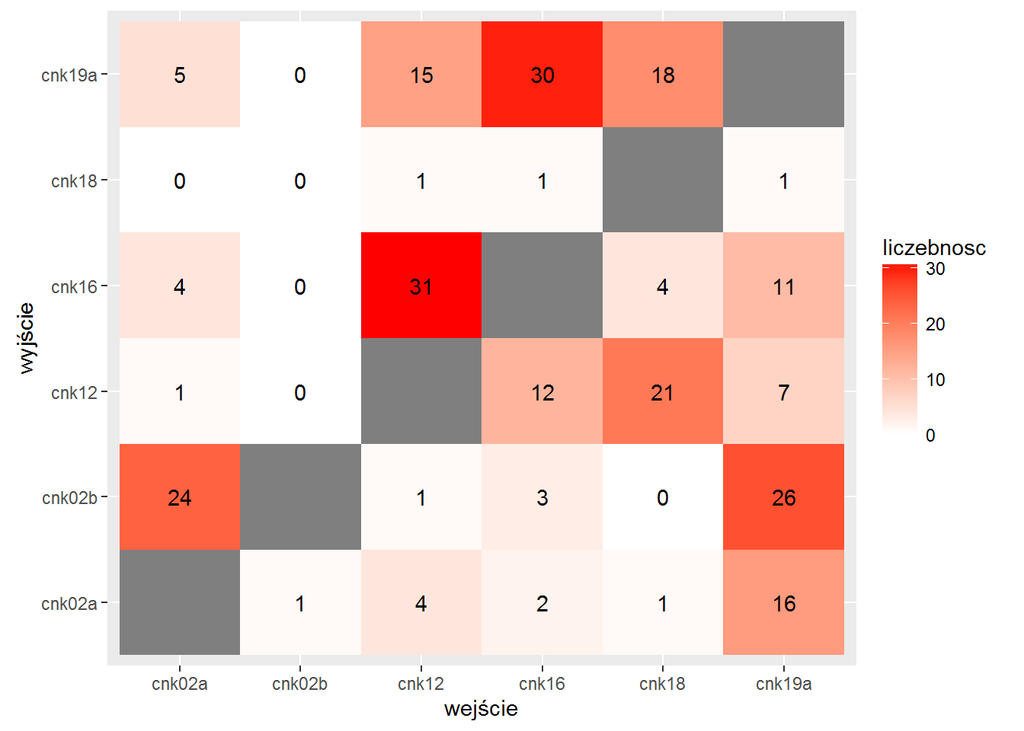

Macierz składająca się z liczby przejść pomiędzy najbardziej popularnymi stacjami (cnk02, cnk12, cnk16, cnk18, cnk19) wśród osób, które odwiedziły ponad 20 eskponatów.

# Reguły asocjacyjne

Oprócz wpływu bezpośredniego, ciekawe ekspozycje popularnych stacji mogą także rozbudzać zainteresowanie całą wystawą, a przez to wpływać na odwiedzenie jakichś konkretnych stacji. Analizę pośredniego wpływu przedstawimy zarówno biorąc jak i nie biorąc pod uwagę kolejność zwiedzania (w pierwszym przypadku możliwe jest to, że sam zamiar odwiedzenia konkretnej stacji odbijał się później na decyzjach zwiedzających).

## Analiza całej populacji zwiedzających

### Bez uwzględnienia kolejności zwiedzania

Analiza decyzji odwiedzających po pierwsze uwidacznia, że większość zauważonych regularności dotyczy reguł, w których po prawej stronie wynikania występują najpopularniejsze stacje. Możemy wskazać jednak, że do odwiedzenia mniej popularnych stacji najbardziej inspirująca była stacja cnk12.

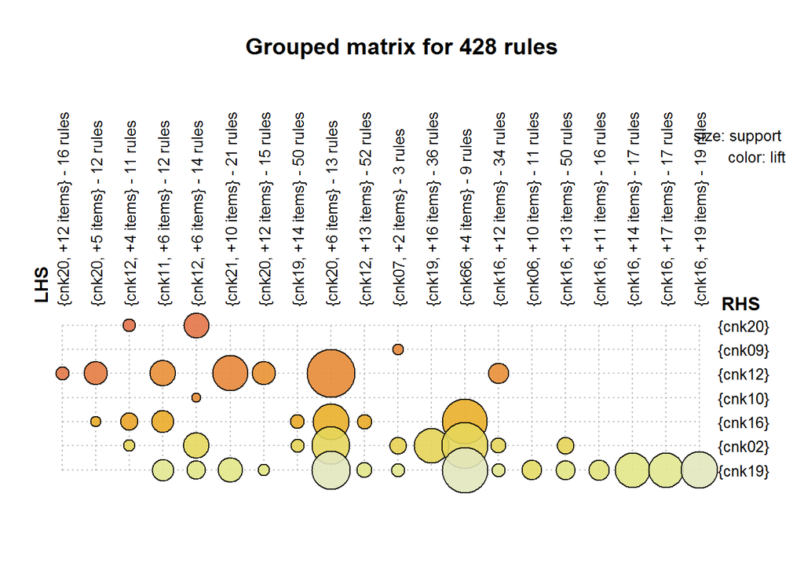

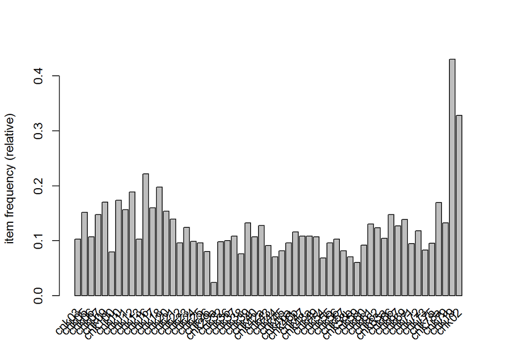

Trzeba jednak zaznaczyć, iż znalezione reguły nie miały zbyt wysokiego poziomu support - co namniej 0,02.

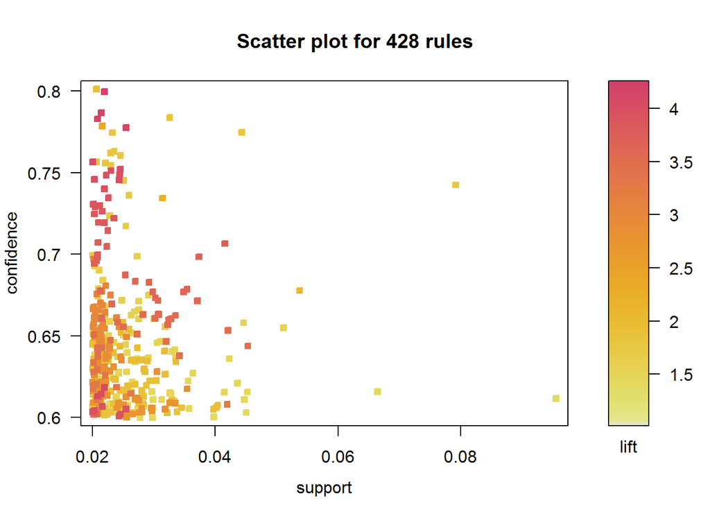

### Z uwględnieniem kolejności zwiedzania

Sytuacja przedstawia się inaczej gdy weźmiemy pod uwagę kolejność odwiedzanych stacji. Za pomocą pakietu arulesSequences zbadano najczęstsze sekwencje zwiedzania - na poziomie support 0.02 oraz dla maksymalnej długości 3.

```
##                sequence support
## 238 <{cnk63a},{cnk63a}>    0.06
## 315 <{cnk02a},{cnk58b}>    0.06
## 492 <{cnk46a},{cnk46a}>    0.06
## 804 <{cnk19b},{cnk19b}>    0.06
## 252  <{cnk19a},{cnk62}>    0.06
## 486  <{cnk16},{cnk46a}>    0.06
## 512  <{cnk02a},{cnk44}>    0.06
## 891  <{cnk02a},{cnk11}>    0.06
## 972  <{cnk19a},{cnk06}>    0.06
## 985  <{cnk19a},{cnk05}>    0.06
## 140   <{cnk10},{cnk72}>    0.06
## 158   <{cnk07},{cnk71}>    0.06
## 171   <{cnk71},{cnk71}>    0.06
## 199   <{cnk10},{cnk67}>    0.08
```

[output cut: 16 more lines]

```
##                          sequence support
## 78      <{cnk11},{cnk40},{cnk79}>    0.02
## 115     <{cnk66},{cnk75},{cnk75}>    0.02
## 116    <{cnk02a},{cnk75},{cnk75}>    0.02
## 133    <{cnk02a},{cnk73},{cnk73}>    0.02
## 134    <{cnk25},{cnk19a},{cnk73}>    0.02
## 154     <{cnk11},{cnk72},{cnk72}>    0.02
## 155     <{cnk06},{cnk49},{cnk72}>    0.02
## 174    <{cnk100},{cnk71},{cnk71}>    0.02
## 175     <{cnk10},{cnk71},{cnk71}>    0.02
## 196    <{cnk10},{cnk78a},{cnk69}>    0.02
## 197    <{cnk02a},{cnk49},{cnk69}>    0.02
## 242   <{cnk26},{cnk63a},{cnk63a}>    0.02
## 243   <{cnk02a},{cnk24},{cnk63a}>    0.02
## 258    <{cnk19a},{cnk62},{cnk62}>    0.02
```

[output cut: 49 more lines]

W przypadku sekwencji o maksymalnej długości 3 widać, że jako początek sekwencji wyróżniają się stacje cnk02a, cnk02b, cnk19 oraz cnk18. Tak jak na poprzedniej mapie, z nich odwiedzający przechodzą do eksponatów w drugiej części galerii. Przejścia między mniej popularnymi maszynami (zazwyczaj drugie przejście w sekwencji) wymuszane są raczej przez układ maszyn.

Analiza sekwencji wyróżnia więc stację początkową cnk02 oraz, w mniejszym stopniu, stacje cnk18 i cnk19, co jest dość niezgodne z wnioskami wyciągniętymi z analizy reguł asocjacyjnych (bez kolejności).

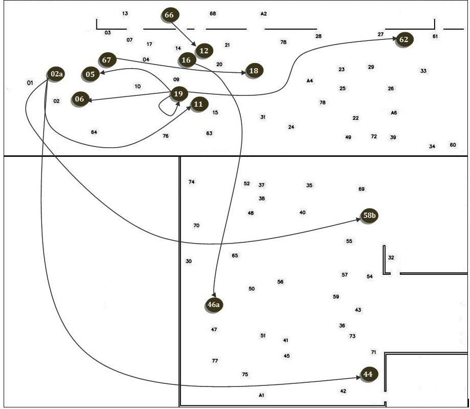

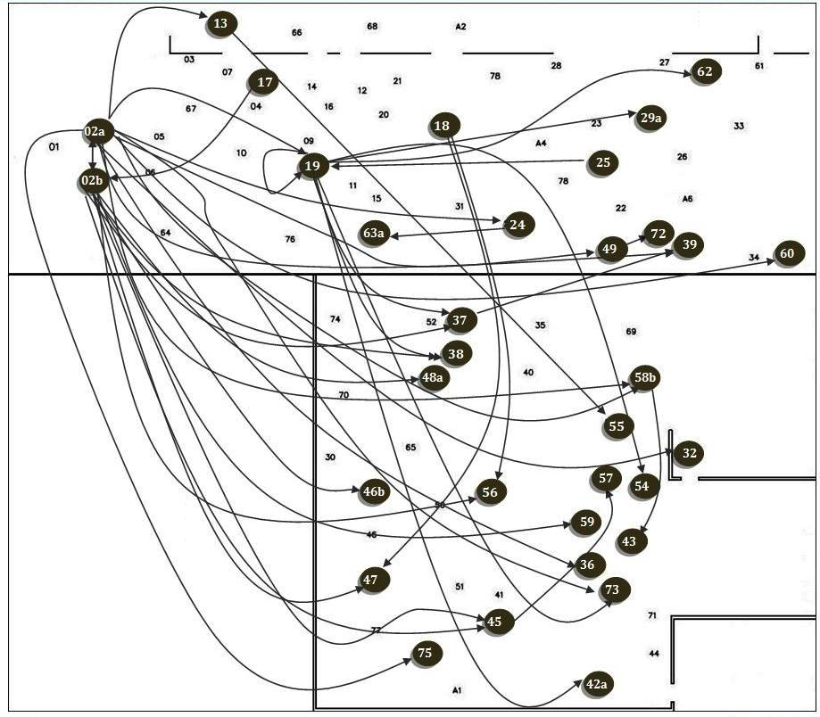